# Biostat M280 Homework 3

Due Mar 3 @ 11:59PM

## Q1 LA City Employee Payroll

The `/home/m280-data/la_payroll/LA_City_Employee_Payroll.csv` file on teaching server contains payroll information of LA City employees in years 2013-2017. It was downloaded from [LA City Controller’s Office](https://controllerdata.lacity.org/Payroll/City-Employee-Payroll/pazn-qyym). Make a Shiny app to facilitate exploratory data analysis.

1. For efficiency of the Shiny app, you should first pre-process, pare down, tidy, and save the data, e.g., as a compressed RDS file, to be used in the app.

```r
##prepare:
library(tidyverse)
library(shiny)
fluidPage()
```

```r
payroll <- read_csv("/home/m280-data/la_payroll/LA_City_Employee_Payroll.csv")
###### Data set for question 1 ######
TotPay_wide <- payroll %>%
  group_by(Year) %>%
  summarise(base = sum(as.numeric(gsub("\\$", "", `Base Pay`)), na.rm = TRUE),
            overtime = sum(as.numeric(gsub("\\$", "", `Overtime Pay`)),
                           na.rm = TRUE),
            other = sum(as.numeric(gsub("\\$", "", `Other Pay (Payroll Explorer)`
                                        )), na.rm = TRUE),
            total = sum(base, overtime, other))
Totpay <- gather(TotPay_wide, class, payment, base:other, factor_key=TRUE)
write_rds(Totpay, "LAPayrolls/totpay.rds")

###### Data set for question 2 ######
highpay <- payroll %>%
select(Year, `Department Title`, `Job Class Title`, `Total Payments`, `Base Pay`,
       `Overtime Pay`,`Other Pay (Payroll Explorer)`) %>%
  arrange(Year, desc(as.numeric(gsub("\\$", "", `Total Payments`))))
write_rds(highpay, "LAPayrolls/highpay.rds")

###### Data set for question 3 ######
meanpay <- payroll %>%
  group_by(Year,`Department Title`) %>%
  summarise(`Mean Total Pay` =  mean(as.numeric(gsub("\\$", "",`Total Payments`)),
                                    na.rm = TRUE),
            `Mean Base Pay` = mean(as.numeric(gsub("\\$", "", `Base Pay`)),
                                   na.rm = TRUE),
            `Mean Overtime Pay` = mean(as.numeric(gsub("\\$", "",`Overtime Pay`)),
                                       na.rm = TRUE),
            `Mean Other Pay` =  mean(as.numeric(gsub("\\$", "",
                                    `Other Pay (Payroll Explorer)`)),
                                    na.rm = TRUE)
            ) %>% arrange( Year, desc( `Mean Total Pay` ))
write_rds(meanpay, "LAPayrolls/meanpay.rds")

medpay <- payroll %>%
  group_by(`Department Title`, Year) %>%
  summarise(`Median Total Pay` =  median(as.numeric(gsub("\\$", "",`Total Payments`)),
                                    na.rm = TRUE),
            `Median Base Pay` = median(as.numeric(gsub("\\$", "", `Base Pay`)),
                                   na.rm = TRUE),
            `Median Overtime Pay` = median(as.numeric(gsub("\\$", "",`Overtime Pay`)),
                                       na.rm = TRUE),
            `Median Other Pay` =  median(as.numeric(gsub("\\$", "",
                                    `Other Pay (Payroll Explorer)`)),
                                    na.rm = TRUE)
            ) %>%  arrange( Year, desc( `Median Total Pay` ) )
write_rds(medpay, "LAPayrolls/medpay.rds")

###### Data set for question 4 ######
cost <- payroll %>%
  group_by(Year,`Department Title`) %>%
  summarise(`Total Pay` =  sum(as.numeric(gsub("\\$", "",`Total Payments`)),
                                    na.rm = TRUE),
            `Base Pay` = sum(as.numeric(gsub("\\$", "", `Base Pay`)),
                                   na.rm = TRUE),
            `Overtime Pay` = sum(as.numeric(gsub("\\$", "",`Overtime Pay`)),
                                       na.rm = TRUE),
            `Other Pay` =  sum(as.numeric(gsub("\\$", "",
                                    `Other Pay (Payroll Explorer)`)),
                                     na.rm = TRUE),
            `Total Cost` = sum(as.numeric(gsub("\\$", "", `Average Benefit Cost`)),
                                       na.rm = TRUE)
            ) %>% arrange( Year, desc( `Total Cost` )) %>%
            select(Year, `Department Title`, `Total Pay`, `Base Pay`,
                   `Overtime Pay`, `Other Pay`, `Total Cost`)
write_rds(cost, "LAPayrolls/cost.rds")

#plan
plan <- payroll %>%
  filter(!is.na(`Benefits Plan`)) %>%
  group_by(Year, `Benefits Plan`) %>%
  summarise(n = n())
write_rds(plan, "LAPayrolls/plan.rds")
```

0. Publish your Shiny app to https://www.shinyapps.io and share the link.

The link is https://huiyuhu.shinyapps.io/LAPayrolls. The first four tabs corresponds the four questions. The last tab shows the distribution of the health plans for each year.

## Q2 LA City Parking War

The SQLite database `/home/m280-data/la_parking/LA_Parking_Citations.sqlite` on teaching server contains information about parking tickets in LA City. It was downloaded from [LA Open Data Portal](https://data.lacity.org/A-Well-Run-City/Parking-Citations/wjz9-h9np). Connect to the database and answer following questions using plots and summary statistics. In this exercise, you are **not** allowed to load whole data into memory. Use the *transform in database, plot in R* strategy.

```r
#Prepare
library("DBI")
library("RSQLite")
library("tidyverse")
library("lubridate")
library("magrittr")
#Connect
con = dbConnect(RSQLite::SQLite(),
                "/home/m280-data/la_parking/LA_Parking_Citations.sqlite")
newcon = dbConnect(RSQLite::SQLite(),
                   "/home/m280-data/la_parking/LA_Parking_Citations_Extra.sqlite")
str(con)
```

```
## Formal class 'SQLiteConnection' [package "RSQLite"] with 6 slots
##   ..@ ptr                :<externalptr>
##   ..@ dbname             : chr "/home/m280-data/la_parking/LA_Parking_Citations.sqlite"
##   ..@ loadable.extensions: logi TRUE
##   ..@ flags              : int 70
##   ..@ vfs                : chr ""
##   ..@ ref                :<environment: 0xa246c40>
```

```r
str(newcon)
```

```
## Formal class 'SQLiteConnection' [package "RSQLite"] with 6 slots
##   ..@ ptr                :<externalptr>
##   ..@ dbname             : chr "/home/m280-data/la_parking/LA_Parking_Citations_Extra.sqlite"
##   ..@ loadable.extensions: logi TRUE
##   ..@ flags              : int 70
##   ..@ vfs                : chr ""
##   ..@ ref                :<environment: 0x9af01d0>
```

```r
dbListTables(con)
```

```
## [1] "latix"
```

```r
dbListTables(newcon)
```

```
## [1] "latix"
```

```r
latix_sql <- dplyr::tbl(con, "latix")
latix_new <- dplyr::tbl(newcon, "latix")
str(latix_sql)
```

```
## List of 2
##  $ src:List of 2
##   ..$ con  :Formal class 'SQLiteConnection' [package "RSQLite"] with 6 slots
##   .. .. ..@ ptr                :<externalptr>
##   .. .. ..@ dbname             : chr "/home/m280-data/la_parking/LA_Parking_Citations.sqlite"
##   .. .. ..@ loadable.extensions: logi TRUE
##   .. .. ..@ flags              : int 70
##   .. .. ..@ vfs                : chr ""
##   .. .. ..@ ref                :<environment: 0xa246c40>
##   ..$ disco: NULL
##   ..- attr(*, "class")= chr [1:3] "src_dbi" "src_sql" "src"
##  $ ops:List of 2
##   ..$ x   :Classes 'ident', 'character'  chr "latix"
##   ..$ vars: chr [1:18] "Ticket_number" "Issue_DateTime" "Meter_Id" "Marked_Time" ...
##   ..- attr(*, "class")= chr [1:3] "op_base_remote" "op_base" "op"
##  - attr(*, "class")= chr [1:4] "tbl_dbi" "tbl_sql" "tbl_lazy" "tbl"
```

```r
str(latix_new)
```

```
## List of 2
##  $ src:List of 2
##   ..$ con  :Formal class 'SQLiteConnection' [package "RSQLite"] with 6 slots
##   .. .. ..@ ptr                :<externalptr>
##   .. .. ..@ dbname             : chr "/home/m280-data/la_parking/LA_Parking_Citations_Extra.sqlite"
##   .. .. ..@ loadable.extensions: logi TRUE
##   .. .. ..@ flags              : int 70
##   .. .. ..@ vfs                : chr ""
##   .. .. ..@ ref                :<environment: 0x9af01d0>
##   ..$ disco: NULL
##   ..- attr(*, "class")= chr [1:3] "src_dbi" "src_sql" "src"
##  $ ops:List of 2
##   ..$ x   :Classes 'ident', 'character'  chr "latix"
##   ..$ vars: chr [1:23] "Ticket_number" "Issue_Year" "Issue_Month" "Issue_Day" ...
##   ..- attr(*, "class")= chr [1:3] "op_base_remote" "op_base" "op"
##  - attr(*, "class")= chr [1:4] "tbl_dbi" "tbl_sql" "tbl_lazy" "tbl"
```

```r
knitr::opts_chunk$set(connection = "con")
knitr::opts_chunk$set(connection = "newcon")
```

1. How many tickets are in this data set? Which time period do these tickets span? Which years have most data?

```sql
SELECT COUNT(DISTINCT Ticket_number) AS tick_num FROM latix;
```

1 records

| tick_num |
| --- |
| 4044338 |

Another way to do this:

```r
latix_sql %>%
   summarise(n = n())
```

```
## # Source:   lazy query [?? x 1]
## # Database: sqlite 3.19.3
## #   [/home/m280-data/la_parking/LA_Parking_Citations.sqlite]
##         n
##     <int>
## 1 4044488
```

- There are `4044488` tickets; after removing the NA data there are `4044338` tickets (distinct) in this data sets (since sql always removed the na data).

```sql
SELECT DATETIME(MAX(Issue_DateTime), 'unixepoch') AS "Max TIME",
        DATETIME(MIN(Issue_DateTime), 'unixepoch') AS "Min TIME"
FROM latix;
```

1 records

| Max TIME | Min TIME |
| --- | --- |
| 2017-12-30 01:41:00 | 2010-04-27 21:40:00 |

Another way to do this:

```r
maxtime <- latix_new %>%
  arrange(desc(Issue_Year), desc(Issue_Month), desc(Issue_Day),
          desc(Issue_Hour),  desc(Issue_Minute),na.rm=TRUE) %>%
  head(1) %>%
  select(Issue_Year, Issue_Month, Issue_Day, Issue_Hour, Issue_Minute)
maxtime
```

```
## # Source:     lazy query [?? x 5]
## # Database:   sqlite 3.19.3
## #   [/home/m280-data/la_parking/LA_Parking_Citations_Extra.sqlite]
## # Ordered by: desc(Issue_Year), desc(Issue_Month), desc(Issue_Day),
## #   desc(Issue_Hour), desc(Issue_Minute), TRUE
##   Issue_Year Issue_Month Issue_Day Issue_Hour Issue_Minute
##        <int>       <int>     <int>      <int>        <int>
## 1       2017          12        30          1           41
```

```r
mintime <- latix_new %>%
  filter(!is.na(Issue_Year) && !is.na(Issue_Month) && !is.na(Issue_Day) &&
        !is.na(Issue_Hour) && !is.na(Issue_Minute)) %>%
  arrange(Issue_Year, Issue_Month, Issue_Day,
          Issue_Hour,  Issue_Minute, na.rm=TRUE) %>%
  head(1) %>%
  select(Issue_Year, Issue_Month, Issue_Day, Issue_Hour, Issue_Minute)
mintime
```

```
## # Source:     lazy query [?? x 5]
## # Database:   sqlite 3.19.3
## #   [/home/m280-data/la_parking/LA_Parking_Citations_Extra.sqlite]
## # Ordered by: Issue_Year, Issue_Month, Issue_Day, Issue_Hour,
## #   Issue_Minute, TRUE
##   Issue_Year Issue_Month Issue_Day Issue_Hour Issue_Minute
##        <int>       <int>     <int>      <int>        <int>
## 1       2010           4        27         21           40
```

- The time period is `from 2010-04-27 21:40:00 UTC to 2017-12-30 01:41:00 UTC`.

```sql
SELECT
  strftime('%Y', DATETIME(Issue_DateTime, 'unixepoch')) AS Year,
  COUNT(*) AS Number
FROM latix
WHERE Issue_DateTime IS NOT NULL
GROUP BY 1
ORDER BY 2 DESC
LIMIT  1;
```

1 records

| Year | Number |
| --- | --- |
| 2015 | 2161119 |

By another way:

```r
latix_new %>%
  filter(!is.na(Issue_Year)) %>%
  group_by(Issue_Year) %>%
  summarise(n = n()) %>%
  arrange(desc(n)) %>%
  head(1)
```

```
## # Source:     lazy query [?? x 2]
## # Database:   sqlite 3.19.3
## #   [/home/m280-data/la_parking/LA_Parking_Citations_Extra.sqlite]
## # Ordered by: desc(n)
##   Issue_Year       n
##        <int>   <int>
## 1       2015 2161119
```

- `2015` has most of the data.
0. When (which hour, weekday, month day, and month) are you most likely to get a ticket and when are you least likely to get a ticket?
- For Hour:

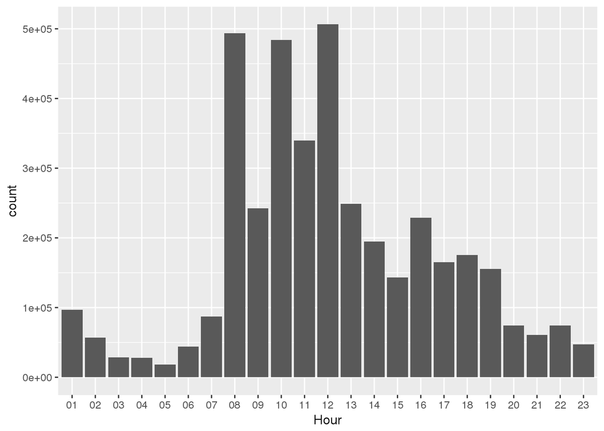

```r
sqlstr_hour <-
  "SELECT
    strftime('%H', DATETIME(Issue_DateTime, 'unixepoch')) AS Hour
  FROM latix
  WHERE Issue_DateTime IS NOT NULL
"
hour <- dbGetQuery(con, sqlstr_hour)
ggplot(hour, aes(Hour)) + geom_bar()
```

```r
latix_new %>%
  select(Issue_Hour) %>%
  filter(!is.na(Issue_Hour)) %>%
  group_by(Issue_Hour) %>%
  summarise(n = n()) %>%
  arrange(desc(n))
```

```
## # Source:     lazy query [?? x 2]
## # Database:   sqlite 3.19.3
## #   [/home/m280-data/la_parking/LA_Parking_Citations_Extra.sqlite]
## # Ordered by: desc(n)
##    Issue_Hour      n
##         <int>  <int>
##  1         12 506580
##  2          8 493591
##  3         10 483765
##  4         11 339373
##  5         13 249057
##  6          9 242181
##  7         16 229036
##  8         14 194789
##  9         18 175190
## 10         17 165014
## # ... with more rows
```

- Based on the barchart above, it most likely to get a ticket at `12` and least likely to get a ticket at `5`. In addition, the summary of count can also confirm this result.
- For weekday:

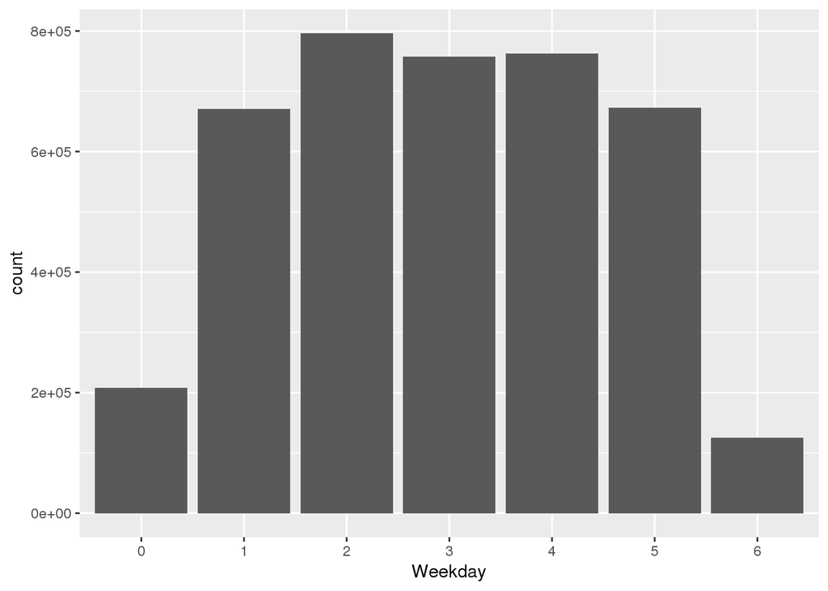

```r
sqlstr_weekday <-
  "SELECT
    strftime('%w', DATETIME(Issue_DateTime, 'unixepoch')) AS Weekday
  FROM latix
  WHERE Issue_DateTime IS NOT NULL
"
weekday <- dbGetQuery(con, sqlstr_weekday)
ggplot(weekday, aes(Weekday)) + geom_bar()
```

```r
latix_new %>%
  select(Issue_Wday) %>%
  filter(!is.na(Issue_Wday)) %>%
  group_by(Issue_Wday) %>%
  summarise(n = n()) %>%
  arrange(desc(n))
```

```
## # Source:     lazy query [?? x 2]
## # Database:   sqlite 3.19.3
## #   [/home/m280-data/la_parking/LA_Parking_Citations_Extra.sqlite]
## # Ordered by: desc(n)
##   Issue_Wday      n
##        <dbl>  <int>
## 1       3.00 796643
## 2       5.00 762375
## 3       4.00 757085
## 4       6.00 673039
## 5       2.00 671009
## 6       1.00 207926
## 7       7.00 125327
```

- Based on the barchart above, it most likely to get a ticket on `Tuesday` and least likely to get a ticket on `Saturday`. In addition, the summary of count can also confirm this result.
- For month day:

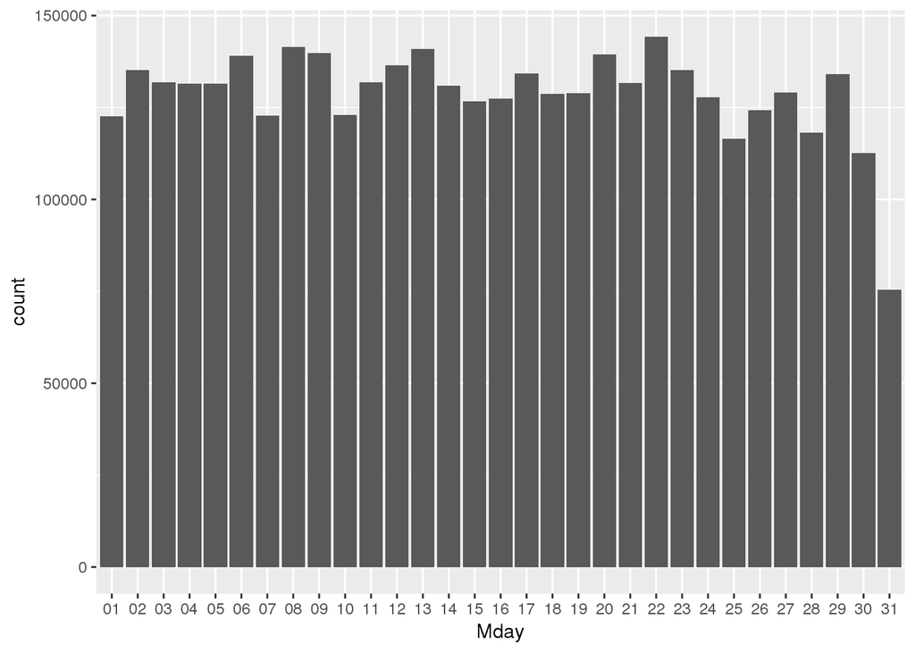

```r
sqlstr_mday <-
  "SELECT
    strftime('%d', DATETIME(Issue_DateTime, 'unixepoch')) AS Mday
  FROM latix
  WHERE Issue_DateTime IS NOT NULL
"
mday <- dbGetQuery(con, sqlstr_mday)
ggplot(mday, aes(Mday)) + geom_bar()
```

```r
latix_new %>%
  select(Issue_Day) %>%
  filter(!is.na(Issue_Day)) %>%
  group_by(Issue_Day) %>%
  summarise(n = n()) %>%
  arrange(desc(n))
```

```
## # Source:     lazy query [?? x 2]
## # Database:   sqlite 3.19.3
## #   [/home/m280-data/la_parking/LA_Parking_Citations_Extra.sqlite]
## # Ordered by: desc(n)
##    Issue_Day      n
##        <int>  <int>
##  1        22 144331
##  2         8 141418
##  3        13 140911
##  4         9 139844
##  5        20 139399
##  6         6 139001
##  7        12 136397
##  8        23 135277
##  9         2 135131
## 10        17 134300
## # ... with more rows
```

- Based on the barchart above, it most likely to get a ticket on day `22` in a month and least likely to get a ticket on day `31` in a month. In addition, the summary of count can also confirm this result.
- For month:

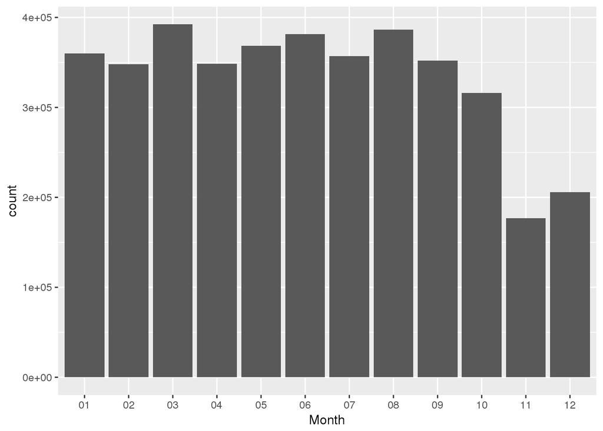

```r
sqlstr_month <-
  "SELECT
    strftime('%m', DATETIME(Issue_DateTime, 'unixepoch')) AS Month
  FROM latix
  WHERE Issue_DateTime IS NOT NULL
"
month <- dbGetQuery(con, sqlstr_month)
ggplot(month, aes(Month)) + geom_bar()
```

```r
latix_new %>%
  select(Issue_Month) %>%
  filter(!is.na(Issue_Month)) %>%
  group_by(Issue_Month) %>%
  summarise(n = n()) %>%
  arrange(desc(n))
```

```
## # Source:     lazy query [?? x 2]
## # Database:   sqlite 3.19.3
## #   [/home/m280-data/la_parking/LA_Parking_Citations_Extra.sqlite]
## # Ordered by: desc(n)
##    Issue_Month      n
##          <int>  <int>
##  1           3 392473
##  2           8 386605
##  3           6 381378
##  4           5 368248
##  5           1 360127
##  6           7 357247
##  7           9 352063
##  8           4 348320
##  9           2 348145
## 10          10 315881
## # ... with more rows
```

- Based on the barchart above, it most likely to get a ticket in `March` and least likely to get a ticket in `November`. In addition, the summary of count can also confirm this result.
0. Which car makes received most citations?

```r
sqlstr_car <-
 "SELECT
    Make AS Car,
    COUNT(*) AS Number
  FROM latix
  WHERE Make IS NOT NULL
  GROUP BY 1
  ORDER BY 2 DESC
  LIMIT 1
"
dbGetQuery(con, sqlstr_car)
```

```
##    Car Number
## 1 TOYT 669548
```

- By another method:

```r
latix_new %>%
  filter(!is.na(Make)) %>%
  group_by(Make) %>%
  summarise(n = n()) %>%
  arrange(desc(n)) %>%
  head(1)
```

```
## # Source:     lazy query [?? x 2]
## # Database:   sqlite 3.19.3
## #   [/home/m280-data/la_parking/LA_Parking_Citations_Extra.sqlite]
## # Ordered by: desc(n)
##   Make       n
##   <chr>  <int>
## 1 TOYT  669548
```

- The `TOYOTA` received most citations.
0. How many different colors of cars were ticketed? Which color attracted most tickets?

```r
qlstr_color <-
 "SELECT
    Color AS Color,
    COUNT(*) AS Number
  FROM latix
  WHERE Color IS NOT NULL
  GROUP BY 1
  ORDER BY 2 DESC
"
color <- dbGetQuery(con, qlstr_color)
color[1,]
```

```
##   Color Number
## 1    BK 862283
```

```r
nrow(color)
```

```
## [1] 65
```

- By another way:

```r
colordata <- latix_new %>%
  filter(!is.na(Color)) %>%
  group_by(Color) %>%
  summarise(n = n()) %>%
  arrange(desc(n))

colordata %>%
  summarise(n = n())
```

```
## # Source:   lazy query [?? x 1]
## # Database: sqlite 3.19.3
## #   [/home/m280-data/la_parking/LA_Parking_Citations_Extra.sqlite]
##       n
##   <int>
## 1    65
```

```r
colordata %>%
  head(1)
```

```
## # Source:     lazy query [?? x 2]
## # Database:   sqlite 3.19.3
## #   [/home/m280-data/la_parking/LA_Parking_Citations_Extra.sqlite]
## # Ordered by: desc(n)
##   Color      n
##   <chr>  <int>
## 1 BK    862283
```

- There are `65` different colors of cars were ticketed. The `Black` car attracted most tickets.
0. What are the most common ticket types?

```r
latix_new %>%
  filter(!is.na(Violation_Description)) %>%
  group_by(Violation_Description) %>%
  summarise(n = n()) %>%
  arrange(desc(n)) %>%
  head(1)
```

```
## # Source:     lazy query [?? x 2]
## # Database:   sqlite 3.19.3
## #   [/home/m280-data/la_parking/LA_Parking_Citations_Extra.sqlite]
## # Ordered by: desc(n)
##   Violation_Description       n
##   <chr>                   <int>
## 1 NO PARK/STREET CLEAN  1149021
```

- The most common is `NO PARK/STREET CLEAN`;
0. How much money was collected on parking tickets in 2015 and 2016?

```r
sqlstr_money <-
  "SELECT
    strftime('%Y', DATETIME(Issue_DateTime, 'unixepoch')) AS Year,
    SUM(Fine_amount) AS Money
  FROM latix
  WHERE Issue_DateTime IS NOT NULL
  GROUP BY 1
"
money <- dbGetQuery(con, sqlstr_money)
money[money$Year == "2015",2]
```

```
## [1] 151006794
```

```r
money[money$Year == "2016",2]
```

```
## [1] 123236136
```

```r
money[money$Year == "2015",2] + money[money$Year == "2016",2]
```

```
## [1] 274242930
```

Another solution by using dplyr. Unix Epoch 1420070400, and 1483228799 corresponds to 2015-01-01:00:00:00 and 2016-12-31:23:59:59 GMT, respectively.

```r
amount <- latix_new %>%
  select(Fine_amount, Issue_Year) %>%
  filter(Issue_Year == 2015 || Issue_Year == 2016,
         !is.na(Fine_amount), !is.na(Issue_Year))
amount %>%
  group_by(Issue_Year) %>%
  summarise(amount = sum(Fine_amount, na.rm = T))
```

```
## # Source:   lazy query [?? x 2]
## # Database: sqlite 3.19.3
## #   [/home/m280-data/la_parking/LA_Parking_Citations_Extra.sqlite]
##   Issue_Year    amount
##        <int>     <int>
## 1       2015 151006794
## 2       2016 123236136
```

```r
amount %>%
  summarize(total = sum(Fine_amount, na.rm = TRUE))
```

```
## # Source:   lazy query [?? x 1]
## # Database: sqlite 3.19.3
## #   [/home/m280-data/la_parking/LA_Parking_Citations_Extra.sqlite]
##       total
##       <int>
## 1 274242930
```

- 2015: `$ 151006794`; 2016: `$ 123236136`; Total`$ 274242930` was collected on parking tickets in 2015 and 2016.
0. Visualize any other information you are interested in.
- which state plate is most common?

```r
latix_new %>%
  filter(!is.na(RP_State_Plate)) %>%
  group_by(RP_State_Plate) %>%
  summarise(n = n()) %>%
  arrange(desc(n)) %>%
  head(1)
```

```
## # Source:     lazy query [?? x 2]
## # Database:   sqlite 3.19.3
## #   [/home/m280-data/la_parking/LA_Parking_Citations_Extra.sqlite]
## # Ordered by: desc(n)
##   RP_State_Plate       n
##   <chr>            <int>
## 1 CA             3766908
```

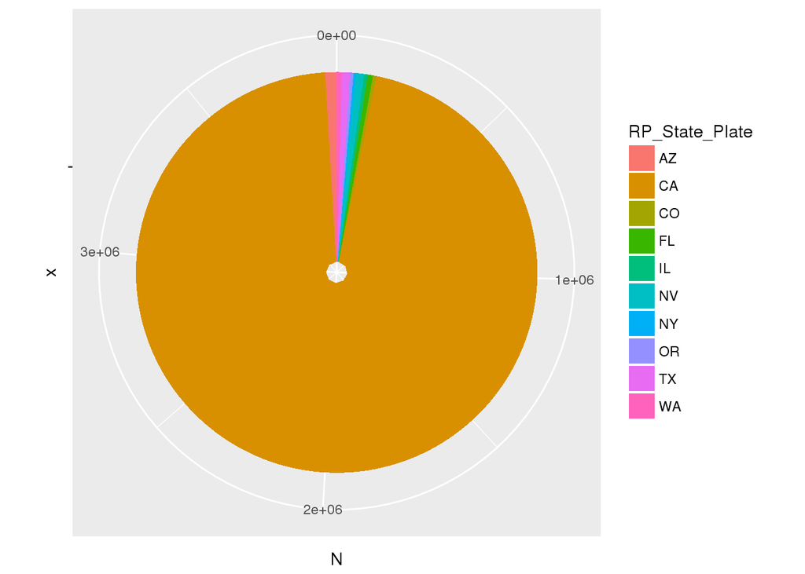

```r
plate_sql <-
  "SELECT
    RP_State_Plate AS RP_State_Plate,
    COUNT(*) AS N
  FROM latix
  WHERE RP_State_Plate IS NOT NULL
  GROUP BY 1
  ORDER BY 2 DESC
"
plate <- dbGetQuery(con, plate_sql)
plate %>%
  head(10) %>%
  ggplot(aes(x = "", y = N, fill = RP_State_Plate)) +
  geom_bar(stat = "identity") +
  coord_polar(theta = "y")
```

- `CA` plate attracted most tickets.